# DigitalDNA-Rpackage

WAFI-CNR 01/09/2019

## Installation

```r
install.packages("devtools", repos = "http://cran.us.r-project.org")
library(devtools)
devtools::install_github("WAFI-CNR/ddna-rpackage")
```

## How to use

```r
library(ddna)
df <- sequence_tweets_from_file("timelines.json", alphabet="b3_type")
str(df)
```

```
## 'data.frame':    6 obs. of  2 variables:
##  $ user_id: Factor w/ 6 levels "1135017996","22834067",..: 5 3 2 4 6 1
##  $ seq    : Factor w/ 6 levels "AAAAAAAAAAACAAACCAAAACAAAAAAAAAAAAAATAATAAATTAAAAAATCAAAACAAACAAAAAAACAAAACAACAAAACAACACAAAATACAAAACAAACCCCAACA"| __truncated__,..: 6 3 5 2 1 4
```

The package allows you to upload a CSV with already encoded DNA

```r
df <- read.csv2("italian_retweets_users_sequences_new.csv", sep = ",")
str(df)
```

# Plot Bases distribution

It is possible to observe the distribution of each base of the chosen alphabet. For each base it will be plotted a boxplot. The function accepts as a parameter the index of the dataframe column of the codified timeline (default 3).

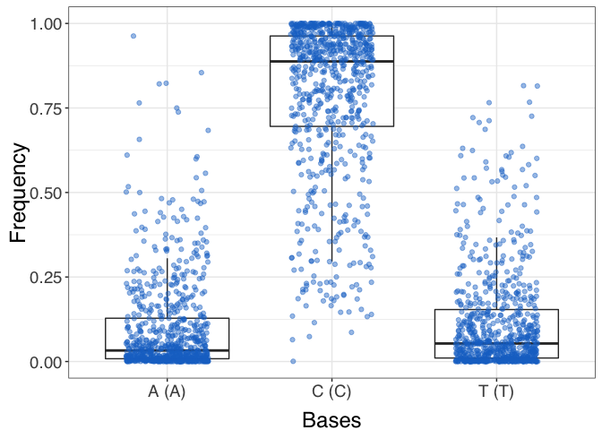

```r
plot_bases_distribution(df, dnacol = 3)
```

## Plot interseq entropy

This function produces a composite plot. On the left a boxplot representing the distribution of the inter-sequence entropy (Shannon’s Entropy of the letters in the same with same sequence index but in different sequences). On the right a scatterplot of the entropies ordered by sequence index. “You can pass”plot_interseq" accept the column index in which there is the DNA sequence as a parameter (default=2).

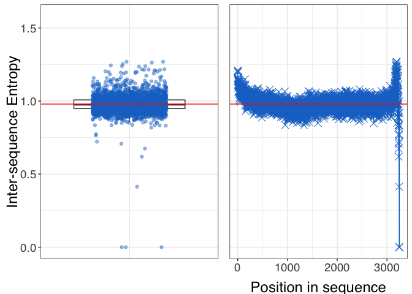

```r
plot_interseq(df, dnacol = 3)
```

## Intrasequence Entropy plot

This function produces a box plot with a single box representing the distribution of the intra-sequence entropies (the Shannon Entropy computed over a single digital dna sequence).

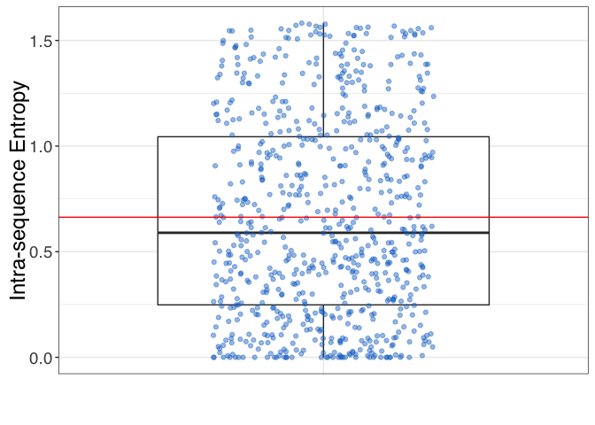

```r
plot_intraseq(df, dnacol = 3)
```

# LCS plot

The lcs plot function compute the longest common sequences among DDNA strings. It accepts as parameters a threshold and a window. Threshold indicates possible bots accounts and it can be calculated on the lcs curve derived and smoothed by a running mean (threshold = “auto”) or assigned as a integer (threshold = x). Window parameter set the running mean window (neighbourhood). The lcs lenght column must be labelled as “dna”.

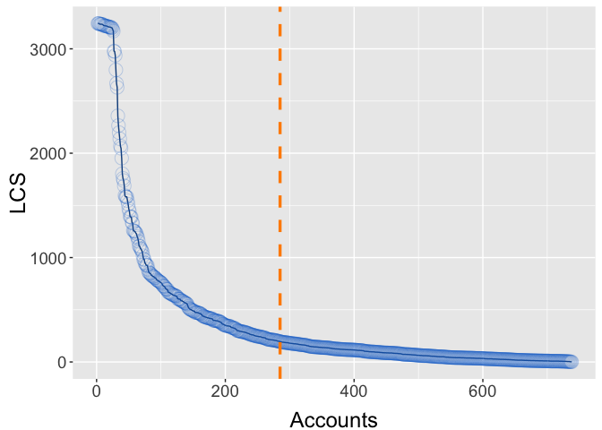

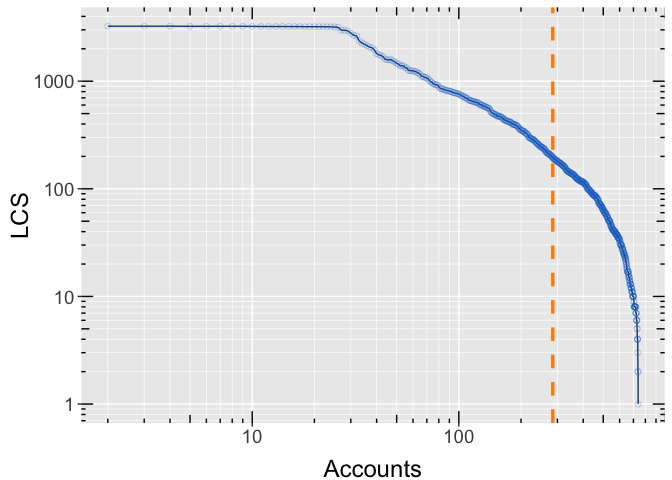

```r
lcs_plot(df, threshold = "auto", window = 10)
```

# Bots detection

“predicts_bots” produces a single column dataframe (logical) which identifies possible bot accounts.

```r
bots = predict_bots(df, threshold = "auto", window = 10)
```

```
## bots
## FALSE  TRUE
##   454   284
```

## Plot Sequence Color

This function plots codified timelines colored according to the chosen alphabet. Timelines are plotted in deacresing order according to their length.

[figure not shown]

```r
plot_sequences_by_color(df, dnacol = 3)
```